# Data Science Project 1: EDA with Walmart data - 3 variables (Weather, Holiday, Weekday)

Alex

2026-03-02

## Description of variables

```r
library(ezids)
WMT  = read.csv(file = "~/GitHub/26SP_DATS6101_PROJECT1/Walmart.csv", header = TRUE) #replace with your own file path to the Walmart data set
```

Each of these variables will be compared against the variable “category” to tell us if the given variables influence preference toward appliances or electronics:

A. “weather_conditions” is a character variable with four levels: “Sunny”, “Cloudy”, “Rainy”, and “Stormy”. These are not ordered.

```r
unique(WMT$weather_conditions)
```

```
## [1] "Stormy" "Rainy"  "Sunny"  "Cloudy"
```

B. “weekday” is a character variable with the days of the week as levels. We have used the factor() function to order them 1-7 starting with “Monday”.

```r
WMT$weekday = factor(WMT$weekday, levels = c("Monday", "Tuesday", "Wednesday", "Thursday", "Friday", "Saturday", "Sunday"), ordered = TRUE)
str(WMT$weekday)
```

```
##  Ord.factor w/ 7 levels "Monday"<"Tuesday"<..: 5 1 2 7 4 6 7 4 6 1 ...
```

C. “holiday_indicator” is a binary logical variable that was recorded as TRUE for transactions taking place on a holiday. Let’s view this category next to the transaction dates to figure out if these are only national holidays or a larger set.

```r
str(WMT$holiday_indicator)
```

```
##  logi [1:5000] FALSE FALSE FALSE TRUE FALSE TRUE ...
```

## Holiday Determinance

```r
HOLIDAYS = data.frame(WMT$transaction_date, WMT$holiday_indicator)
head(HOLIDAYS, 15)
```

```
##    WMT.transaction_date WMT.holiday_indicator
## 1       3/31/2024 21:46                 FALSE
## 2       7/28/2024 12:45                 FALSE
## 3        6/10/2024 4:55                 FALSE
## 4        8/15/2024 1:03                  TRUE
## 5        9/13/2024 0:45                 FALSE
## 6         7/6/2024 7:24                  TRUE
## 7       3/17/2024 22:33                 FALSE
## 8       7/22/2024 13:57                  TRUE
## 9        3/30/2024 4:10                  TRUE
## 10      6/17/2024 16:59                  TRUE
## 11       4/3/2024 11:37                 FALSE
## 12      6/19/2024 10:41                  TRUE
## 13        3/1/2024 4:08                  TRUE
## 14      6/24/2024 17:34                  TRUE
## 15      7/11/2024 11:58                 FALSE
```

We can see from the HOLIDAYS DataFrame that these holidays likely refer to promotional periods run by Walmart surrounding national and other holidays such as July 4th, Juneteenth, etc, rather than single days. However, we would need more data or another document to confirm this.

```r
WMT$category = factor(WMT$category, levels = c("Electronics", "Appliances"), ordered = FALSE)
WMT$weather_conditions = factor(WMT$weather_conditions, levels = c("Stormy", "Rainy", "Sunny", "Cloudy"), ordered = FALSE)

WMT_Alex = data.frame(WMT$category, WMT$weekday, WMT$weather_conditions, WMT$holiday_indicator)
summary(WMT_Alex)
```

```
##       WMT.category     WMT.weekday  WMT.weather_conditions
##  Electronics:2585   Monday   :775   Stormy:1233
##  Appliances :2415   Tuesday  :736   Rainy :1218
##                     Wednesday:691   Sunny :1268
##                     Thursday :760   Cloudy:1281
##                     Friday   :668
##                     Saturday :710
##                     Sunday   :660
##  WMT.holiday_indicator
##  Mode :logical
##  FALSE:2501
##  TRUE :2499
##
##
##
##
```

We have also isolated the data set to the primary independent variable (Category) and the three contextual variables, (day of the week), (weather conditions), and (Holiday). The dependent variable is number of transactions.

## Bar Charts

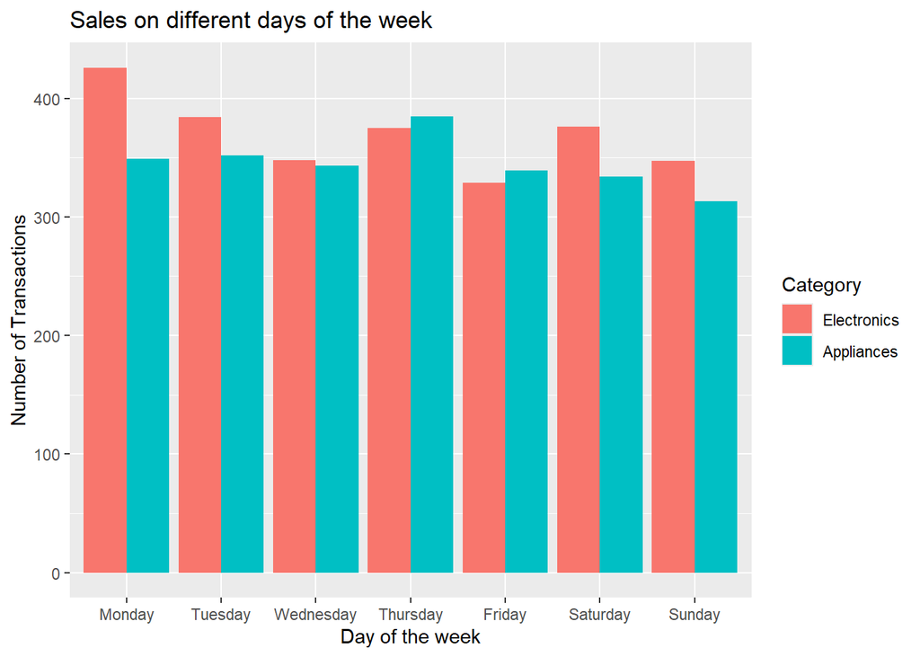

```r
library(ggplot2)
ggplot(WMT_Alex, aes(x = WMT.weekday, fill = WMT.category)) + geom_bar(position = "dodge") + labs(x = "Day of the week", y = "Number of Transactions",title = "Sales on different days of the week", fill = "Category")
```

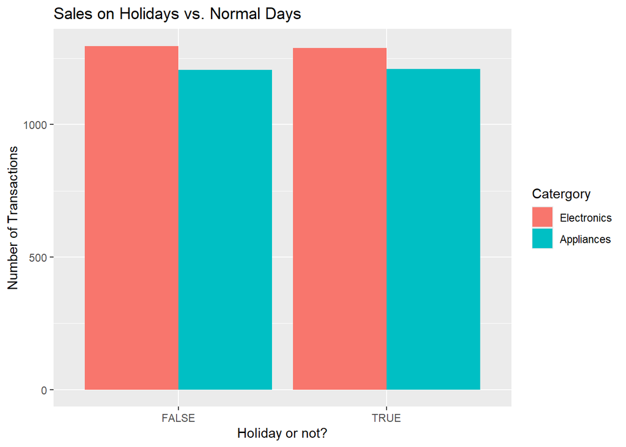

```r
ggplot(WMT_Alex, aes(x = WMT.holiday_indicator,  fill = WMT.category)) + geom_bar(position = "dodge") + labs(x = "Holiday or not?", y = "Number of Transactions", title = "Sales on Holidays vs. Normal Days", fill = "Catergory", )
```

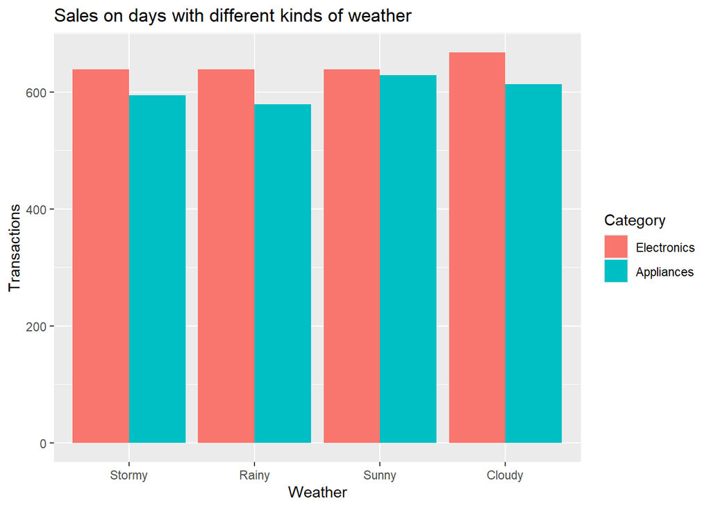

```r
ggplot(WMT_Alex, aes(x = WMT.weather_conditions, fill = WMT.category)) + geom_bar(position = "dodge") + labs(x = "Weather", y = "Transactions", title = "Sales on days with different kinds of weather", fill = "Category")
```

There is no clear trend indicating that any of the three qualifiers affect the sales of electronics versus appliances. Overall, electronics sell better but not by much. Next we’ll use Chi tests to confirm whether these variables are independent.

## Chi-Squared Testing

```r
WMT_E = subset(WMT_Alex, WMT_Alex$WMT.category == "Electronics")
WMT_A = subset(WMT_Alex, WMT_Alex$WMT.category == "Appliances")
```

### 1. Day of the week (Alpha = 0.05)

Electronics:

- Null (H.0) hypothesis: Day of the week does not affect electronics sales
- Hypothesis 1 (H.1): Day of the week does affect electronics sales

Appliances:

- H.0: Day of the week does not affect appliance sales
- H.1: Day of the week does affect appliance sales

```r
Week_table_E = table(WMT_E$WMT.weekday)
head(Week_table_E)
```

```
##
##    Monday   Tuesday Wednesday  Thursday    Friday  Saturday
##       426       384       348       375       329       376
```

```r
print(chisq.test(Week_table_E))
```

```
##
##  Chi-squared test for given probabilities
##
## data:  Week_table_E
## X-squared = 16.474, df = 6, p-value = 0.01143
```

```r
Week_table_A = table(WMT_A$WMT.weekday)
head(Week_table_A)
```

```
##
##    Monday   Tuesday Wednesday  Thursday    Friday  Saturday
##       349       352       343       385       339       334
```

```r
print(chisq.test(Week_table_A))
```

```
##
##  Chi-squared test for given probabilities
##
## data:  Week_table_A
## X-squared = 8.2609, df = 6, p-value = 0.2196
```

### 2. Holiday presence (Alpha = 0.05)

Electronics:

- H.0: The presence of a holiday does not affect electronics sales
- H.1: The presence of a holiday does affect electronics sales

Appliances:

- H.0: The presence of a holiday does not affect appliance sales
- H.1: The presence of a holiday does affect appliance sales

```r
Holiday_E = table(WMT_E$WMT.holiday_indicator)
head(Holiday_E)
```

```
##
## FALSE  TRUE
##  1296  1289
```

```r
print(chisq.test(Holiday_E))
```

```
##
##  Chi-squared test for given probabilities
##
## data:  Holiday_E
## X-squared = 0.018956, df = 1, p-value = 0.8905
```

```r
Holiday_A = table(WMT_A$WMT.holiday_indicator)
head(Holiday_A)
```

```
##
## FALSE  TRUE
##  1205  1210
```

```r
print(chisq.test(Holiday_A))
```

```
##
##  Chi-squared test for given probabilities
##
## data:  Holiday_A
## X-squared = 0.010352, df = 1, p-value = 0.919
```

### 3. Type of Weather (alpha = 0.05)

Electronics:

- H.0: The weather has no impact on sales of electronics
- H.1: The weather has an impact on sales of electronics

Appliances:

- H.0: The weather has no impact on sales of appliances
- H.1: The weather has an impact on sales of appliances

```r
Weather_E = table(WMT_E$WMT.weather_conditions)
head(Weather_E)
```

```
##
## Stormy  Rainy  Sunny Cloudy
##    639    639    639    668
```

```r
print(chisq.test(Weather_E))
```

```
##
##  Chi-squared test for given probabilities
##
## data:  Weather_E
## X-squared = 0.97602, df = 3, p-value = 0.8071
```

```r
Weather_A = table(WMT_A$WMT.weather_conditions)
head(Weather_A)
```

```
##
## Stormy  Rainy  Sunny Cloudy
##    594    579    629    613
```

```r
print(chisq.test(Weather_A))
```

```
##
##  Chi-squared test for given probabilities
##
## data:  Weather_A
## X-squared = 2.3698, df = 3, p-value = 0.4993
```

## Conclusions

1. For day of the week and electronics sales, we can reject the null hypothesis since p < a. This indicates that day of the week may imapct sales of electronics. We fail to reject the null for appliance sales, indicating that day of the week does not impact sales of appliances.
2. For holidays, we fail to reject the null for sales of both categories, indicating that whether or not it is a holiday does not impact sales of either (p > a in both cases).
3. For type of weather, we fail to reject the null for sales of both categories, indicating that the type of weather does not impact sales of either (p > a in both cases).